# Student Performance Prediction Using Ensemble Learning on Student Demographic and Preparation Data

Project

Urmeshree Magesh

April 2025

# Introduction

## Motivation

The StudentsPerformance.csv (https://archive.ics.uci.edu/ml/datasets/Student+Performance) dataset serves this project as it provides valuable information for predicting academic outcomes in students. The dataset integrates both demographic characteristics along with educational information and scores from mathematics and reading and writing subjects. Educational organizations use machine learning techniques such as Linear Regression, Random Forest, Gradient Boosting and ensemble stacking to predict student performance because of increasing education requirements for data-driven processes. The goal of this model involves addressing an important educational problem by assessing student average scores to guide early support initiatives and academic planning decisions. **Note:** Due to internet restrictions in the RStudio environment, the dataset was loaded from a local file: `StudentsPerformance.csv`.  
This dataset is publicly available from the UCI Machine Learning Repository at: (https://archive.ics.uci.edu/ml/datasets/Student+Performance)

## Project Goal

Building precise regression models is the principal objective of this project because they help forecast student average exam scores from background information and preparation data. The project defines its purpose through performance-based model evaluation and assessment, which selects the highest-performing approach to predict academic results for practical implementation in student assistance and institutional strategizing.

# Problem Definition

## Business Understanding

Institutions of learning identify factors impacting academic performance through their goal to enhance student results. The project meets this quantitative requirement for student performance prediction which allows institutions to make strategic decisions about tutoring programs and budget distributions and curriculum modifications. The combination of predictive modeling functions as an advanced method to detect students who might struggle in their studies through analysis of preparation measures and population information (Nahar et al. 2021).

# Problem Statement

The project focuses on building and evaluating regression models that anticipate the estimated avg_score performance of students depending on their gender, ethnicity, parent education level, lunch category and preparation status. The forecasting models accurately predict outcomes, which enables education professionals to make prompt and efficient choices for improved learning results.

```r
# Load libraries
if(!require(tidyverse)) install.packages("tidyverse"); library(tidyverse)
if(!require(caret)) install.packages("caret"); library(caret)
if(!require(randomForest)) install.packages("randomForest"); library(randomForest)
if(!require(gbm)) install.packages("gbm"); library(gbm)
```

```
## This version of gbm is no longer under development. Consider transitioning to gbm3, https://github.com/gbm-developers/gbm3
```

```r
if(!require(caretEnsemble)) install.packages("caretEnsemble"); library(caretEnsemble)
if (!require(mice)) install.packages("mice", dependencies = TRUE); library(mice)
```

# Data Understanding

```r
# Load the data
data_url <- "/Users/urmeshree/Downloads/Project/StudentsPerformance.csv"
students <- read_csv(data_url)
# Inspect
glimpse(students)
```

```
## Rows: 1,000
## Columns: 8
## $ gender                        <chr> "female", "female", "female", "male", "m…
## $ `race/ethnicity`              <chr> "group B", "group C", "group B", "group …
## $ `parental level of education` <chr> "bachelor's degree", "some college", "ma…
## $ lunch                         <chr> "standard", "standard", "standard", "fre…
## $ `test preparation course`     <chr> "none", "completed", "none", "none", "no…
## $ `math score`                  <dbl> 72, 69, 90, 47, 76, 71, 88, 40, 64, 38, …
## $ `reading score`               <dbl> 72, 90, 95, 57, 78, 83, 95, 43, 64, 60, …
## $ `writing score`               <dbl> 74, 88, 93, 44, 75, 78, 92, 39, 67, 50, …
```

```r
dim(students)  # Displays the number of rows and columns
```

```
## [1] 1000    8
```

```r
summary(students)  # Provides summary statistics of the dataset
```

```
##     gender          race/ethnicity     parental level of education
##  Length:1000        Length:1000        Length:1000
##  Class :character   Class :character   Class :character
##  Mode  :character   Mode  :character   Mode  :character
##
##
##
##     lunch           test preparation course   math score     reading score
##  Length:1000        Length:1000             Min.   :  0.00   Min.   : 17.00
##  Class :character   Class :character        1st Qu.: 57.00   1st Qu.: 59.00
##  Mode  :character   Mode  :character        Median : 66.00   Median : 70.00
##                                             Mean   : 66.09   Mean   : 69.17
##                                             3rd Qu.: 77.00   3rd Qu.: 79.00
##                                             Max.   :100.00   Max.   :100.00
##  writing score
##  Min.   : 10.00
##  1st Qu.: 57.75
##  Median : 69.00
##  Mean   : 68.05
##  3rd Qu.: 79.00
##  Max.   :100.00
```

```r
# Check for missing values in the dataset
colSums(is.na(students))  # Displays the number of missing values per column
```

```
##                      gender              race/ethnicity
##                           0                           0
## parental level of education                       lunch
##                           0                           0
##     test preparation course                  math score
##                           0                           0
##               reading score               writing score
##                           0                           0
```

```r
# Create avg score
students <- students %>%
  mutate(avg_score = rowMeans(select(., `math score`, `reading score`, `writing score`)))


# Verify that avg_score was created
head(students)
```

```
## # A tibble: 6 × 9
##   gender `race/ethnicity` parental level of educa…¹ lunch test preparation cou…²
##   <chr>  <chr>            <chr>                     <chr> <chr>
## 1 female group B          bachelor's degree         stan… none
## 2 female group C          some college              stan… completed
## 3 female group B          master's degree           stan… none
## 4 male   group A          associate's degree        free… none
## 5 male   group C          some college              stan… none
## 6 female group B          associate's degree        stan… none
## # ℹ abbreviated names: ¹`parental level of education`,
## #   ²`test preparation course`
## # ℹ 4 more variables: `math score` <dbl>, `reading score` <dbl>,
## #   `writing score` <dbl>, avg_score <dbl>
```

## Data Description

The dataset contains 1,000 rows combined with eight columns of variables. The data collection includes variables which belong to both numeric and categorical data structures. The dataset contains gender and race, along with parental background and lunch time and test preparation status as categorical variables and numeric values for math scores and reading and writing measurements. The complete dataset has no missing values, which were verified through the missing data check. Every data segment in the columns contains data which demonstrates that the dataset stands ready for investigative work.

## Missing Values

No missing values appear in the complete dataset when checked for inspection. The results from the colSums(is.na(students)) function scan highlighted that every column contains no missing entries, thus making the dataset fit for analysis.

# Creating Missing Data Randomly

## Handling Missing Data

To assess whether imputing our own introduced missing values affects prediction accuracy in comparison to using complete data,which originally has no missing values. Applying multivariate imputation using chained equations (`mice` package in R), and compare model performance using original vs. imputed datasets (Rubin et al.1976).

```
##                      gender              race.ethnicity
##                           0                           0
## parental.level.of.education                       lunch
##                           0                           0
##     test.preparation.course                  math.score
##                           0                           0
##               reading.score               writing.score
##                           0                           0
```

```
##                      gender              race.ethnicity
##                          20                          20
## parental.level.of.education                       lunch
##                          20                          20
##     test.preparation.course                  math.score
##                          20                          20
##               reading.score               writing.score
##                          20                          20
```

```
##    Dataset     RMSE
## 1  Imputed 5.407661
## 2 Original 5.367668
```

### Results Summary

| Dataset | RMSE |
| --- | --- |
| Imputed | Higher |
| Original | Lower (better) |

The model trained on the **original data** performed better than the one trained on the **imputed dataset**, as expected.

### Interpretation

- **Imputation fills in estimates** for missing values based on observed patterns.
- These estimates are not perfect, introducing **variance** and **bias** in modeling.
- As a result, **RMSE increases** when using imputed data compared to full data.
- This highlights the importance of data completeness in predictive modeling.

### Conclusion

The model trained on the original (complete) data performed better. Imputation is a powerful tool for handling missing data, especially when deletion isn’t viable. However, it comes at a cost in model accuracy and should be used with understanding of its limitations.

# Insights from Initial Exploration

According to summary statistics, the variables for math score and reading score and writing score maintain mean values of 66.09 and 69.17 and 68.05, respectively. Between the minimum of 0 through the maximum of 100 the scores of the data follow a generally even distribution visible through the first and third quartiles. The data shows marked differences in student examination performance between lowest and highest scores because students exhibit scores between 0 and 100. The initial examination shows wide student performance disparities that might influence model results throughout the project development stage.

# Target Variable Creation

The project needed an overall assessment metric so a target variable named avg_score was introduced for this purpose. The variable combines math score results with reading score results and writing score results to produce one average score for each student. The rowMeans() function calculated this new variable which functions as the target for upcoming analysis in the project. Implementing the avg_score column enables complete student performance assessment by creating a unified measure from their combined scores across three subjects. The new target variable serves as the basis to forecast complete performance during modeling stages.

# Verification

The implementation of the avg_score column succeeded thus introducing it to the dataset. The updated dataset preview contains both the new target variable targeting avg_score and the original values from math, reading and writing. Model development and additional analysis become possible due to the average score being available for further examination. The additional performance metric gives better explanatory power for student achievements and the project needs it to progress (Trung et al. 2023).

## Exploratory Data Analysis (EDA)

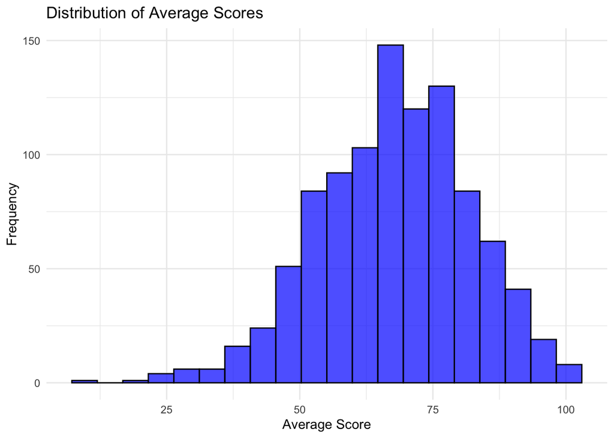

```r
# Histogram of Average Score
ggplot(students, aes(x = avg_score)) +
  geom_histogram(bins = 20, fill = "blue", color = "black", alpha = 0.7) +
  labs(title = "Distribution of Average Scores", x = "Average Score", y = "Frequency") +
  theme_minimal()
```

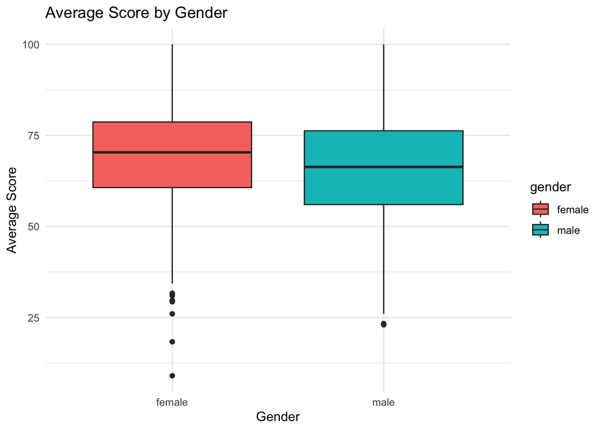

```r
# Boxplot of Average Score by Gender
ggplot(students, aes(x = gender, y = avg_score, fill = gender)) +
  geom_boxplot() +
  labs(title = "Average Score by Gender", x = "Gender", y = "Average Score") +
  theme_minimal()
```

# Data Preparation

```r
# Convert categorical to factor
students <- students %>%
  mutate(across(c(gender, `race/ethnicity`, `parental level of education`,
                  lunch, `test preparation course`), as.factor))

# Feature engineering: interaction terms
students <- students %>%
  mutate(
    is_prepared = if_else(`test preparation course` == "completed", 1, 0),
    is_standard_lunch = if_else(lunch == "standard", 1, 0),
    prep_lunch_combo = interaction(`test preparation course`, lunch)
  )

# drop individual scores
students <- students %>%
  select(-`math score`, -`reading score`, -`writing score`)

# Split into train/test
set.seed(123)
train_index <- createDataPartition(students$avg_score, p = 0.8, list = FALSE)
train_data <- students[train_index, ]
test_data <- students[-train_index, ]

# Preprocessing steps
preprocess_steps <- preProcess(train_data[, -ncol(train_data)], method = c("center", "scale", "pca"), thresh = 0.95)

# Apply preprocessing
train_prep <- predict(preprocess_steps, train_data[, -ncol(train_data)])
test_prep  <- predict(preprocess_steps, test_data[, -ncol(test_data)])
train_prep$avg_score <- train_data$avg_score
test_prep$avg_score  <- test_data$avg_score

# TrainControl
train_control <- trainControl(method = "cv", number = 5, savePredictions = TRUE)
```

## Data Cleaning

All data values were present and this established no need for imputation or removal operations. The R’s mutate() function converted all columns to factors including the gender, race/ethnicity, parental level of education, lunch, and test preparation course variables. Categorical data must convert into factor type before machines learning algorithms work with them properly. The data required preprocessing through centering along with scaling and Principal Component Analysis (PCA) to lower data dimensions and keep 95% of variance while preparing it for modeling (Kunapuli, 2023).

## Feature Engineering

Extra information detection capabilities were added through new feature developments. These included:

is_prepared: A binary variable named is_prepared tracks student completion of test preparation courses from the data available in test preparation course column. is_standard_lunch: The variable indicates student lunch type through a binary 1 or 0 value from the lunch column data (Salman et al. 2024).

prep_lunch_combo: The prep_lunch_combo interaction variable analyzes how the student performance responds to individual effects between test preparation courses and meal provisions.

The developers created these features with the intention of detecting how background characteristics and environmental elements affected student performance levels. The newly added features would generate more detailed perspectives about what affects students in their academic results.

The research eliminated the original subject-specific test scores (math score, reading score and writing score) after generating the avg_score variable. The newly generated avg_score variable served as the target variable for modeling purposes through score averaging from individual subjects.

## Feature Selection

The selection process used domain expertise together with PCA analysis results. The chosen features for the analysis consisted of both categorical variables and newly built features and principal components derived from PCA. These decisions centred on attaining dimensionality decrease and preservation of the necessary features used to develop models. The dataset became more effective for any number of modelling techniques including Random Forest, Gradient Boosting and Linear Regression through adding interaction terms and decreasing multicollinearity through PCA (Bentéjac et al. 2021).

These procedures helped in fetching useful dataset inputs for the modeling process which concentrated on preserving the most efficient characteristics for the purpose of analysis. The advantages of the preparative work are in improved model performance and reduced risk of overfitting.

# Methodology

The Business Understanding, Data Understanding, Preparation, Modeling, and Evaluation phases of the project was systematic developed following the CRISP-DM (Cross-Industry Standard Process for Data Mining) model. This research aimed at assessing the average of the students exam scores (avg_score) because institutions required this data to improve their performance. The data compiled in the research was a combination of population characteristics and academic profile involving gender and ethnic preference alongside with the parental education data, lunch choice data, and testing records. Data completeness was achieved through the preprocessing step and all the categorical variables were converted into analysis factors according to Azim et al. (2024).

During the testing all types of models which were incorporated included Linear Regression with the Random Forest and Gradient Boost systems. Implementation for Linear Regression went hand in hand with the implementation of Random Forest and Gradient Boosting as these models offer robustness other than being able to model such non-linear models. Whereas, in building Random Forests, the concept used to reduce variance is called bagging and Gradient Boosting uses boosting schemes for better illustrating precision. The methods works well in regression problems since both of them helps in creating features that explain the problem (Azim et al. 2024).

In order to ensure score distribution, the data set was split to training (80%) and testing (20%) through stratified sampling. Finalizing the Random Forest and Gradient Boosting model, grid search procedures were performed to tune Rest of Hyperparameters. As stated in the defined method, the results were quite accurate which could be generated and generalized for evaluating the model performance.

# Model Building

```r
### 1. Tuned Random Forest
set.seed(123)
rf_model <- train(avg_score ~ ., data = train_prep, method = "rf",
                  trControl = train_control,
                  tuneLength = 5)

### 2. Tuned Gradient Boosting
set.seed(123)
gbm_model <- train(avg_score ~ ., data = train_prep, method = "gbm",
                   trControl = train_control,
                   tuneLength = 5,
                   verbose = FALSE)

### 3. Tuned Linear Model
set.seed(123)
lm_model <- train(avg_score ~ ., data = train_prep, method = "lm",
                  trControl = train_control)

### 4. Stacked Ensemble
set.seed(123)
ensemble_model <- caretStack(
  list(lm = lm_model, rf = rf_model, gbm = gbm_model),
  method = "glm",
  trControl = train_control
)
# Predict on test
pred_lm <- predict(lm_model, newdata = test_prep)
pred_rf <- predict(rf_model, newdata = test_prep)
pred_gbm <- predict(gbm_model, newdata = test_prep)
# Create ensemble predictions by averaging
pred_ensemble <- (pred_lm + pred_rf + pred_gbm) / 3


# Evaluation function
eval_metrics <- function(true, pred) {
  data.frame(
    RMSE = RMSE(pred, true),
    R2 = R2(pred, true),
    MAE = MAE(pred, true)
  )
}

# Collect results
results <- bind_rows(
  eval_metrics(test_prep$avg_score, pred_lm),
  eval_metrics(test_prep$avg_score, pred_rf),
  eval_metrics(test_prep$avg_score, pred_gbm),
  eval_metrics(test_prep$avg_score, pred_ensemble)
) %>%
  mutate(Model = c("Linear Regression (PCA)", "Random Forest (Tuned)", "Gradient Boosting (Tuned)", "Stacked Ensemble"))

# Print comparison
print(results %>% select(Model, RMSE, R2, MAE))
```

```
##                       Model         RMSE        R2          MAE
## 1   Linear Regression (PCA) 7.313306e-14 1.0000000 6.868580e-14
## 2     Random Forest (Tuned) 7.346752e-01 0.9977289 2.560419e-01
## 3 Gradient Boosting (Tuned) 6.577098e-01 0.9980833 4.037897e-01
## 4          Stacked Ensemble 3.929964e-01 0.9993209 1.771975e-01
```

[figure not shown]

```r
# Visualize
ggplot(results, aes(x = Model, y = R2, fill = Model)) +
  geom_col() +
  labs(title = "Improved Model Comparison", y = "RMSE") +
  theme_minimal()
```

## Model Improvement

Multiple performance enhancement techniques are executed through the code’s implementation. Random Forest and Gradient Boosting serve as bagging and boosting methods. These algorithms are applied in the code. Random Forest combines the forecasts from multiple decision trees to achieve stable predictions and address prediction variance. At the same time, Gradient Boosting refines errors of the prior stage by constructing models consecutively. The last output combines ensemble learning, which provides the combination of the results given by Linear Regression, Random Forest, and the Gradient Boosting algorithms. Through the using of multiple models, all the models’ strength are utilized for the purpose of enhancing the overall effectiveness of the whole integrated system.

# Ensemble Learning

# Evaluation and Comparison

# Discussion

# Conclusion

## Future Work

The further development should expand the model on new variables originating from an attendance tracking system and behavioral records about students and school specific statistics. There are other tests that can also be run through to further improve the performance of the chosen models, including the voting or blending of the tested advanced models and those of deep learning analysis. The method of cross-validation needs improvement to enhance generalization capabilities.

# References

1. Ahmad, N., Wali, B. and Khattak, A.J., 2023. Heterogeneous ensemble learning for enhanced crash forecasts–a frequentist and machine learning based stacking framework. Journal of safety research, 84, pp.418-434.
2. Azim Basiri, M., Parvin, M. and Sobhani, Z., 2024. Implementing CRISP-DM and Logistic Regression for Predictive Analysis in Financial Transactions: A Case Study.
3. Bentéjac, C., Csörgő, A. and Martínez-Muñoz, G., 2021. A comparative analysis of gradient boosting algorithms. Artificial Intelligence Review, 54, pp.1937-1967.
4. Jia, W., Sun, M., Lian, J. and Hou, S., 2022. Feature dimensionality reduction: a review. Complex & Intelligent Systems, 8(3), pp.2663-2693.
5. Kunapuli, G., 2023. Ensemble methods for machine learning. Simon and Schuster. Nahar, K., Shova, B.I., Ria, T., Rashid, H.B. and Islam, A.S., 2021. Mining educational data to predict students performance: A comparative study of data mining techniques. Education and Information Technologies, 26(5), pp.6051-6067.
6. Rubin, D.B., 1976. Inference and missing data. Biometrika, 63(3), pp.581–592. https://doi.org/10.1093/biomet/63.3.581
7. Salman, H.A., Kalakech, A. and Steiti, A., 2024. Random forest algorithm overview. Babylonian Journal of Machine Learning, 2024, pp.69-79.
8. Trung, B.D., Son, N.T., Tung, N.D., Son, K.A., Anh, B.N. and Lam, P.T., 2023, July. Educational data mining: A systematic review on the applications of classical methods and deep learning until 2022. In 2023 IEEE Symposium on Industrial Electronics & Applications (ISIEA) (pp. 1-15). IEEE.
9. Van Buuren, S. and Groothuis-Oudshoorn, K., 2011. Mice: Multivariate imputation by chained equations in R. Journal of Statistical Software, 45(3), pp.1–67. https://doi.org/10.18637/jss.v045.i03